# Project 2: Convolutional Networks

Instructions and assignment dates can be found on [github link](https://birsakm.github.io/CS225-2025/). Your submission will be this notebook, with all the outputs embedded in the notebook. We will grade only what we can see in the notebook.

**Note**: This project is open-ended, meaning there are multiple valid solutions. While there are existing implementations of various deep networks for this task available online, plagiarism will NOT be tolerated. Your code will be checked for similarity against online resources as well as submissions from other students. You are expected to justify every design decision during the project evaluation. Any instance of plagiarism will result in a grade of ZERO without prior warning. Throughout the notebook, you will be explicitly instructed when it is appropriate to look up information online.

**Submission note:** We grade the content in this notebook. Make sure outputs are present. You will package everything in a zip file and submit it with the following format: f"P2_{LastName}_{FirstName}.V{version_number}.zip"  
e.g. "P2_Smit_John_V1.zip" - check more details on the announcement

## Introduction

- Your task is to develop a model for single-input image segmentation. The input will be an RGB image, and the output should be a dense classification map, where each pixel represents the predicted probability of belonging to a particular class. Image segmentation is a fundamental computer vision task with numerous practical applications, such as scene understanding and perception.
- We have provided the necessary source code for evaluating your model in `./utils.py`.
- Goals:
  - Get familiar with image segmentation data processing **[20 points]**
  - Implement a [UNet](https://arxiv.org/abs/1505.04597) model that takes an RGB image as input and outputs a dense segmentation map **[30 points]**
  - Define an appropriate loss function **[10 points]**
  - Tune the model to achieve a total Intersection over Union (IoU) score of **0.50** or higher on the provided validation set **[35 points]**
  - Visualize the model prediction **[5 points]**

## Setup

```python
!pip install tqdm datasets timm
```

[output not shown]

```python
import torch
from torchvision.utils import make_grid
import matplotlib.pyplot as plt
import torchvision.transforms.functional as TF
import numpy as np
import torch.optim as optim
import torch.nn as nn
import torch.nn.functional as F
import timm
from torchvision import transforms as T
from PIL import Image
from utils import Metrics
from tqdm.notebook import tqdm
from torch.utils.data import DataLoader
```

```python
IMAGENET_MEAN = [0.485, 0.456, 0.406]
IMAGENET_STD = [0.229, 0.224, 0.225]
```

## Downloading Data & Check

```python
def get_pascal_color_palette():
    """Load the mapping that associates pascal classes with label colors
    Returns:
        np.ndarray with dimensions (21, 3)
    """
    return np.asarray([[0, 0, 0],
                       [128, 0, 0],
                       [0, 128, 0],
                       [128, 128, 0],
                       [0, 0, 128],
                       [128, 0, 128],
                       [0, 128, 128],
                       [128, 128, 128],
                       [64, 0, 0],
                       [192, 0, 0],
                       [64, 128, 0],
                       [192, 128, 0],
                       [64, 0, 128],
                       [192, 0, 128],
                       [64, 128, 128],
                       [192, 128, 128],
                       [0, 64, 0],
                       [128, 64, 0],
                       [0, 192, 0],
                       [128, 192, 0],
                       [0, 64, 128]])

def get_pascal_class_names():
    return ['Background',
            'Aeroplane',
            'Bicycle',
            'Bird',
            'Boat',
            'Bottle',
            'Bus',
            'Car',
            'Cat',
            'Chair',
            'Cow',
            'Diningtable',
            'Dog',
            'Horse',
            'Motorbike',
            'Person',
            'Pottedplant',
            'Sheep',
            'Sofa',
            'Train',
            'Tvmonitor']

def encode_segmap(mask, unk_label=255):
    """Encode segmentation label images as pascal classes
    Args:
        mask (np.ndarray or PIL.Image.Image): raw segmentation label image of dimension
          (M, N, 3), in which the Pascal classes are encoded as colours.
    Returns:
        (np.ndarray): class map with dimensions (M, N), where the value at
        a given location is the integer denoting the class index.
    """
    mask = np.array(mask)
    out_mask = np.ones_like(mask[..., 0]) * unk_label
    for i, color in enumerate(get_pascal_color_palette()):
        # TODO: encode the segmentation map
        # NOTE: you can also completely modify this function
        match_pixels = np.all(mask == color, axis=-1)
        out_mask[match_pixels] = i



    return out_mask

def decode_segmap(mask, unk_label=255):
    """Decode segmentation label prediction as RGB images
    Args:
        mask (torch.tensor): class map with dimensions (B, M, N), where the value at
        a given location is the integer denoting the class index.
    Returns:
        (np.ndarray): colored image of shape (BM, BN, 3)
    """
    if isinstance(mask, torch.Tensor):
        mask = mask.cpu().numpy()
    mask = mask.astype(int)

    out_mask = np.stack([np.ones_like(mask)] * 3, axis=-1) * unk_label
    temp_mask = np.stack([mask] * 3, axis=-1)
    for i, color in enumerate(get_pascal_color_palette()):
        out_mask = np.where(np.all(temp_mask == i, axis=-1, keepdims=True), out_mask * 0 + color, out_mask)

    out_mask[mask==unk_label]=unk_label
    return out_mask
```

### Task 2 [15 points]

- **[5 points]** Please implement a horizontal flip as the data augmentation strategy here.
- It would be fine to add more data augmentations to increase performance, but it does NOT count for extra points. It would be super easy to reach the goal performance without any other augmentation, so no worries.
- **[5 points]** Answer the question: why don't we implement augmentations for the validation/test set?
- **[5 points]** Answer the question: why do we use the NEAREST strategy to resize the mask? Can we use bilinear? What is the difference? Which strategy would be the correct one?

```python
im_transforms = T.Compose([
    T.ToTensor(),
    T.Normalize(mean=IMAGENET_MEAN, std=IMAGENET_STD),
])

def transform_val_voc(batch):
    batch['image'] = [im_transforms(i.resize((256, 256))) for i in batch['image']]
    batch['mask'] = [torch.tensor(encode_segmap(m.resize((256, 256), Image.NEAREST))) for m in batch['mask']]
    return batch

def transform_train_voc(batch):
    batch['image'] = [im_transforms(i.resize((256, 256))) for i in batch['image']]
    batch['mask'] = [torch.tensor(encode_segmap(m.resize((256, 256), Image.NEAREST))) for m in batch['mask']]
    # TODO: implement a horizontal flip here
    # HINTS: the shape of the image and mask tensors is different
    # HINTS: batch['image'][i] = function(batch['image'][i])
    # HINTS: batch['mask'][i] = function(batch['mask'][i])
    for i in range(len(batch['image'])):
        if torch.rand(1).item() > 0.5:
            batch['image'][i] = torch.flip(batch['image'][i], dims=[2]).contiguous()
            batch['mask'][i] = torch.flip(batch['mask'][i], dims=[1]).contiguous()

    return batch
```

```python
ds_voc['train'].set_transform(transform_train_voc)
ds_voc['val'].set_transform(transform_val_voc)
```

```python
def denorm_imagenet(x):
    mean, std = torch.tensor(IMAGENET_MEAN).to(x.device), torch.tensor(IMAGENET_STD).to(x.device)
    if x.ndim == 3:
        mean, std = mean[:, None, None], std[:, None, None]
    elif x.ndim == 4:
        mean, std = mean[None, :, None, None], std[None, :,  None, None]
    return x * std + mean

def show_example_data(dataset, split='train', num=7, subset=False):
    im_list = []
    mask_list = []
    for i in range(num):
        if subset:
            sample = dataset[i]
        else:
            sample = dataset[split][i]
        im_list.append(denorm_imagenet(sample['image']))
        mask_list.append(torch.tensor(decode_segmap(sample['mask'])).permute(2, 0, 1) / 255)

    pairs = [torch.cat([im, mask], dim=1) for im, mask in zip(im_list, mask_list)]
    pairs_grid = make_grid(pairs, nrow=num)
    show(pairs_grid, 'after_transform.png')
```

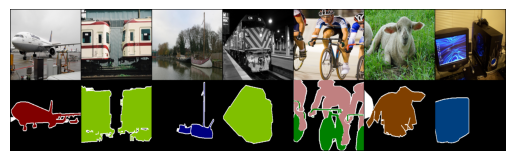

```python
show_example_data(ds_voc, split='val')
```

Run the `show_example_data(ds_voc, split='train')` for multiple times to check if the augmentation works!

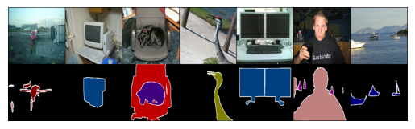

```python
show_example_data(ds_voc, split='train')
```

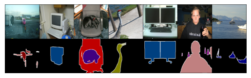

```python
show_example_data(ds_voc, split='train')
```

**Remember to answer the question!**

We don’t use augmentations for validation or test because we need to check real accuracy. If we change images, masks will also change and results become unfair. Validation must show how model works on real, unchanged data.

We use NEAREST to resize the mask because it keeps the mask clean — each pixel stays the same class. If we use bilinear, it mixes colors and makes blurry edges, so classes become wrong. So NEAREST is correct, because every pixel must belong to only one class.

## Getting started with timm

[`timm`](https://timm.fast.ai/) is a deep-learning library created by [Ross Wightman](https://twitter.com/wightmanr) and is a collection of SOTA computer vision models.

We will be using `timm` to load encoder backbones pretrained on ImageNet so we don't have to define encoder architecture) or start training from scrath

```python
BACKBONE = 'resnet18'
```

```python
# timm example for loading any encoder architecture
import timm
import torch

model = timm.create_model(BACKBONE) # load resnet18 architecture
x = torch.randn(1, 3, 224, 224)  # create random input tensor
model(x).shape
```

```
torch.Size([1, 1000])
```

```python
# you can load a pretrained model
model = timm.create_model(BACKBONE, pretrained=True) # load resnet18 architecture
x = torch.randn(1, 3, 224, 224)  # create random input tensor
model(x).shape
```

```
torch.Size([1, 1000])
```

```python
# set features_only as True since we only need features instead of the final ImageNet class logits
model = timm.create_model(BACKBONE, pretrained=True, features_only=True)
x = torch.randn(1, 3, 224, 224)  # create random input tensor
features = model(x)
[f.shape for f in features]
```

```
[torch.Size([1, 64, 112, 112]),
 torch.Size([1, 64, 56, 56]),
 torch.Size([1, 128, 28, 28]),
 torch.Size([1, 256, 14, 14]),
 torch.Size([1, 512, 7, 7])]
```

```python
# set features_only as True since we only need features instead of the final ImageNet class logits
model = timm.create_model(BACKBONE, pretrained=True, features_only=True)
x = torch.randn(1, 3, 256, 256)  # create random input tensor
features = model(x)
[f.shape for f in features]
```

```
[torch.Size([1, 64, 128, 128]),
 torch.Size([1, 64, 64, 64]),
 torch.Size([1, 128, 32, 32]),
 torch.Size([1, 256, 16, 16]),
 torch.Size([1, 512, 8, 8])]
```

```python
# check useful information
model.feature_info.channels()
```

```
[64, 64, 128, 256, 512]
```

```python
# check useful information
model.default_cfg
```

```
{'url': 'https://github.com/huggingface/pytorch-image-models/releases/download/v0.1-rsb-weights/resnet18_a1_0-d63eafa0.pth',
 'hf_hub_id': 'timm/resnet18.a1_in1k',
 'architecture': 'resnet18',
 'tag': 'a1_in1k',
 'custom_load': False,
 'input_size': (3, 224, 224),
 'test_input_size': (3, 288, 288),
 'fixed_input_size': False,
 'interpolation': 'bicubic',
 'crop_pct': 0.95,
 'test_crop_pct': 1.0,
 'crop_mode': 'center',
 'mean': (0.485, 0.456, 0.406),
 'std': (0.229, 0.224, 0.225),
 'pool_size': (7, 7),
 'first_conv': 'conv1',
 'origin_url': 'https://github.com/huggingface/pytorch-image-models',
 'paper_ids': 'arXiv:2110.00476'}
```

```python
# List al available models
avail_pretrained_models = timm.list_models(pretrained=True)

print(f"Number of available pretrained models: {len(avail_pretrained_models)}")
print(f"First 5 models: {avail_pretrained_models[:5]}")
```

```
Number of available pretrained models: 1689
First 5 models: ['aimv2_1b_patch14_224.apple_pt', 'aimv2_1b_patch14_336.apple_pt', 'aimv2_1b_patch14_448.apple_pt', 'aimv2_3b_patch14_224.apple_pt', 'aimv2_3b_patch14_336.apple_pt']
```

**NOTE**

- We don't constrain the usage of encoder architectures in this project. You can use any kind of encoders. But it would still be super easy to reach the goal performance with a pretrained **resnet18**encoder.
- If you are using other encoders, please check the mean and std value listed in the `encoder.default_cfg`. Keep IMAGENET_MEAN and IMAGENET_STD defined at the very beginning position of this notebook aligned with them.

## Model [30 points]

```python
class Unet(nn.Module):
    """
    TODO: Complete the docstring of the Unet class (description, parameters, returns, etc.)
    """

    def __init__(
            self,
            backbone='resnet18',
            num_classes=1,
            # TODO: Add any other relevant args you need
    ):
        super().__init__()
        # TODO: Complete the definition of the Unet class
        # Use timm to load the encoder backbone with imagenet pretrained weights
        # encoder **must** return a list of feature maps that will be used by the decoder
        self.encoder = None
        self.decoder = None

    def forward(self, x: torch.Tensor):
        # TODO: Complete the forward function
        x = None
        return x
```

```python
class Unet(nn.Module):
    """
    TODO: Complete the docstring of the Unet class (description, parameters, returns, etc.)
    """

    def __init__(
            self,
            backbone='resnet18',
            num_classes=21,
            pretrained=True
            # TODO: Add any other relevant args you need
    ):
        super().__init__()
        # TODO: Complete the definition of the Unet class
        # Use timm to load the encoder backbone with imagenet pretrained weights
        # encoder **must** return a list of feature maps that will be used by the decoder
        self.encoder = timm.create_model(
            backbone,
            pretrained=True,
            features_only=True
        )

        enc_ch = self.encoder.feature_info.channels()
        self.decoder = nn.ModuleDict({
            'up4': nn.ConvTranspose2d(enc_ch[4], enc_ch[3], kernel_size=2, stride=2),
            'conv4': self.conv_block(enc_ch[3] + enc_ch[3], enc_ch[3]),

            'up3': nn.ConvTranspose2d(enc_ch[3], enc_ch[2], kernel_size=2, stride=2),
            'conv3': self.conv_block(enc_ch[2] + enc_ch[2], enc_ch[2]),

            'up2': nn.ConvTranspose2d(enc_ch[2], enc_ch[1], kernel_size=2, stride=2),
            'conv2': self.conv_block(enc_ch[1] + enc_ch[1], enc_ch[1]),

            'up1': nn.ConvTranspose2d(enc_ch[1], enc_ch[0], kernel_size=2, stride=2),
            'conv1': self.conv_block(enc_ch[0] + enc_ch[0], enc_ch[0]),

            'up_final': nn.ConvTranspose2d(enc_ch[0], enc_ch[0], kernel_size=2, stride=2),
            'classifier': nn.Conv2d(enc_ch[0], num_classes, kernel_size=1),
        })

    def conv_block(self, in_ch, out_ch):
        return nn.Sequential(
            nn.Conv2d(in_ch, out_ch, kernel_size=3, padding=1),
            nn.ReLU(inplace=True),
            nn.Conv2d(out_ch, out_ch, kernel_size=3, padding=1),
            nn.ReLU(inplace=True)
        )

    def forward(self, x: torch.Tensor):
        # TODO: Complete the forward function
        features = self.encoder(x)
        x = self.decoder['up4'](features[4])
        x = torch.cat([x, features[3]], dim=1)
        x = self.decoder['conv4'](x)

        x = self.decoder['up3'](x)
        x = torch.cat([x, features[2]], dim=1)
        x = self.decoder['conv3'](x)

        x = self.decoder['up2'](x)
        x = torch.cat([x, features[1]], dim=1)
        x = self.decoder['conv2'](x)

        x = self.decoder['up1'](x)
        x = torch.cat([x, features[0]], dim=1)
        x = self.decoder['conv1'](x)


        x = self.decoder['up_final'](x)
        x = self.decoder['classifier'](x)

        return x
```

```python
model = Unet(BACKBONE, num_classes=21)
```

```python
# Always perform a sanity check on the models you define
x = torch.randn(1, 3, 256, 256)
out = model(x)
print("Input shape", x.shape)
print("Output shape", out.shape)
```

```
Input shape torch.Size([1, 3, 256, 256])
Output shape torch.Size([1, 21, 256, 256])
```

## Loss Function [10 points]

```python
def loss_fn(pred_y, y):
    # TODO: implement the loss function (a simple cross-entropy loss would work well)
    criterion = nn.CrossEntropyLoss(ignore_index=255)
    loss = criterion(pred_y, y)

    return loss
```

## Training + Evaluation [35 points]

- **[30 points]** Tune the hyperparameters and the architecture to achieve the target IOU

```python
epochs = 25
batch_size = 8
workers = 4
learning_rate = 1e-3
wd = 1e-4

run_id = f'model_n{epochs}_bs{batch_size}_lr{learning_rate}_wd{wd}'; print('\n\nTraining', run_id)
save_path = run_id + '.pkl'
```

```
Training model_n25_bs8_lr0.001_wd0.0001
```

```python
epochs = 25
batch_size = 16
workers = 4
learning_rate = 1e-3
wd = 1e-4

run_id = f'model_n{epochs}_bs{batch_size}_lr{learning_rate}_wd{wd}'; print('\n\nTraining', run_id)
save_path = run_id + '.pkl'
```

```
Training model_n25_bs16_lr0.001_wd0.0001
```

```python
epochs = 50
batch_size = 16
workers = 4
learning_rate = 1e-3
wd = 1e-4

run_id = f'model_n{epochs}_bs{batch_size}_lr{learning_rate}_wd{wd}'; print('\n\nTraining', run_id)
save_path = run_id + '.pkl'
```

```
Training model_n50_bs16_lr0.001_wd0.0001
```

```python
epochs = 50
batch_size = 16
workers = 4
learning_rate = 1e-4
wd = 1e-4

run_id = f'model_n{epochs}_bs{batch_size}_lr{learning_rate}_wd{wd}'; print('\n\nTraining', run_id)
save_path = run_id + '.pkl'
```

```
Training model_n50_bs16_lr0.0001_wd0.0001
```

```python
epochs = 50
batch_size = 16
workers = 4
learning_rate = 3e-4
wd = 1e-4

run_id = f'model_n{epochs}_bs{batch_size}_lr{learning_rate}_wd{wd}'; print('\n\nTraining', run_id)
save_path = run_id + '.pkl'
```

```
Training model_n50_bs16_lr0.0003_wd0.0001
```

```python
epochs = 50
batch_size = 16
workers = 4
learning_rate = 3e-4
wd = 1e-5

run_id = f'model_n{epochs}_bs{batch_size}_lr{learning_rate}_wd{wd}'; print('\n\nTraining', run_id)
save_path = run_id + '.pkl'
```

```
Training model_n50_bs16_lr0.0003_wd1e-05
```

```python
epochs = 50
batch_size = 16
workers = 4
learning_rate = 5e-4
wd = 1e-4

run_id = f'model_n{epochs}_bs{batch_size}_lr{learning_rate}_wd{wd}'; print('\n\nTraining', run_id)
save_path = run_id + '.pkl'
```

```
Training model_n50_bs16_lr0.0005_wd0.0001
```

```python
epochs = 75
batch_size = 16
workers = 4
learning_rate = 5e-4
wd = 1e-4

run_id = f'model_n{epochs}_bs{batch_size}_lr{learning_rate}_wd{wd}'; print('\n\nTraining', run_id)
save_path = run_id + '.pkl'
```

```
Training model_n75_bs16_lr0.0005_wd0.0001
```

```python
epochs = 100
batch_size = 16
workers = 4
learning_rate = 5e-4
wd = 1e-4

run_id = f'model_n{epochs}_bs{batch_size}_lr{learning_rate}_wd{wd}'; print('\n\nTraining', run_id)
save_path = run_id + '.pkl'
```

```
Training model_n100_bs16_lr0.0005_wd0.0001
```

```python
def init_optimizer(model, lr, wd):
    return optim.AdamW(model.parameters(), lr=lr, weight_decay=wd)

def init_scheduler(optimizer, epochs, train_loader, cycle_momentum, div_factor, final_div_factor, pct_start=0.7):
    lrs = [l['lr'] for l in optimizer.param_groups]
    return optim.lr_scheduler.OneCycleLR(optimizer, lrs, epochs=epochs, steps_per_epoch=len(train_loader),
                                         cycle_momentum=cycle_momentum, div_factor=div_factor,
                                         base_momentum=0.85, max_momentum=0.95,
                                         final_div_factor=final_div_factor, pct_start=pct_start,
                                         three_phase=False)
```

```python
train_loader = DataLoader(ds_voc['train'], batch_size=batch_size, num_workers=workers, shuffle=True)
test_loader = DataLoader(ds_voc['val'], batch_size=1, num_workers=workers, shuffle=False, sampler=None)

ITER_PER_EPOCH = len(train_loader)
TOTAL_STEPS = ITER_PER_EPOCH * epochs

optimizer = init_optimizer(model, learning_rate, wd=wd)
scheduler = init_scheduler(optimizer, epochs, train_loader, cycle_momentum=True, div_factor=25, final_div_factor=10000, pct_start=0.3)
```

```python
model = model.cuda()
```

```python
@torch.no_grad()
def validate(model, valid_loader, tqdm_flag=False, print_results=False):
    metrics = Metrics(len(get_pascal_class_names()), get_pascal_class_names())
    model.eval()
    metrics.reset()

    if tqdm_flag:
        for i, (sample) in tqdm(enumerate(valid_loader), total=len(valid_loader), desc='Validating'):
            x, y = sample['image'].float().cuda(), sample['mask'].numpy()[:, :, :]
            y_pred = model(x)
            y_pred = F.interpolate(y_pred, size=(y.shape[-2:]), mode='nearest')
            y_pred = torch.argmax(y_pred, dim=1).detach().cpu().numpy() # get the most likely prediction
            metrics.add_batch(y, y_pred)
    else:
        for i, sample in enumerate(valid_loader):
            x, y = sample['image'].float().cuda(), sample['mask'].numpy()[:, :, :]
            y_pred = model(x)
            y_pred = F.interpolate(y_pred, size=(y.shape[-2:]), mode='nearest')
            y_pred = torch.argmax(y_pred, dim=1).detach().cpu().numpy() # get the most likely prediction
            metrics.add_batch(y, y_pred)

    table = metrics.get_table()

    if print_results:
        print('\nValidation stats ', table)

    return table.loc['total']['IoU']
```

```python
log_term_dict = dict()
log_term_dict['loss'] = []
log_term_dict['val_metric'] = []
log_term_dict['lr'] = []
loss_log_interval = 100
```

- I have removed one line of the code in the following block, which is the core of the whole training pipeline. Please add it back to make the whole training script complete.

```
Epoch 1, total IoU: 0.0349
Epoch 2, total IoU: 0.0349
Epoch 3, total IoU: 0.0349
Epoch 4, total IoU: 0.0349
Epoch 5, total IoU: 0.0349
Epoch 6, total IoU: 0.04422857142857143
Epoch 7, total IoU: 0.04986190476190476
Epoch 8, total IoU: 0.06628571428571428
Epoch 9, total IoU: 0.07283333333333333
Epoch 10, total IoU: 0.07502380952380952
Epoch 11, total IoU: 0.07956666666666666
Epoch 12, total IoU: 0.09677619047619049
Epoch 13, total IoU: 0.0977857142857143
Epoch 14, total IoU: 0.11806190476190476
Epoch 15, total IoU: 0.13763333333333336
Epoch 16, total IoU: 0.13401428571428572
Epoch 17, total IoU: 0.12246190476190476
Epoch 18, total IoU: 0.16335714285714284
Epoch 19, total IoU: 0.17829047619047617
Epoch 20, total IoU: 0.21423809523809526
Epoch 21, total IoU: 0.19374285714285713
Epoch 22, total IoU: 0.20664285714285716
Epoch 23, total IoU: 0.20843809523809526
Epoch 24, total IoU: 0.2539619047619047
Epoch 25, total IoU: 0.2576761904761905
Epoch 26, total IoU: 0.2570047619047619
Epoch 27, total IoU: 0.31037619047619047
Epoch 28, total IoU: 0.2716523809523809
Epoch 29, total IoU: 0.3059571428571428
Epoch 30, total IoU: 0.2987714285714286
Epoch 31, total IoU: 0.3435619047619047
Epoch 32, total IoU: 0.3655904761904762
Epoch 33, total IoU: 0.40687142857142855
Epoch 34, total IoU: 0.37620476190476193
Epoch 35, total IoU: 0.4184380952380953
Epoch 36, total IoU: 0.30224285714285715
Epoch 37, total IoU: 0.40955714285714284
Epoch 38, total IoU: 0.4479714285714285
Epoch 39, total IoU: 0.4500285714285714
Epoch 40, total IoU: 0.4828523809523811
```

[output cut: 47 more lines]

```
Epoch 88, total IoU: 0.5568666666666666
Epoch 89, total IoU: 0.5576333333333333
Epoch 90, total IoU: 0.5567809523809524
Epoch 91, total IoU: 0.5572952380952382
Epoch 92, total IoU: 0.5589571428571428
Epoch 93, total IoU: 0.5580333333333334
Epoch 94, total IoU: 0.5548476190476189
Epoch 95, total IoU: 0.5554523809523809
Epoch 96, total IoU: 0.5581904761904762
Epoch 97, total IoU: 0.5560095238095238
Epoch 98, total IoU: 0.5564761904761906
Epoch 99, total IoU: 0.5547000000000001
Epoch 100, total IoU: 0.5572190476190476

Training done. Model saved (model_n100_bs16_lr0.0005_wd0.0001.pkl).
```

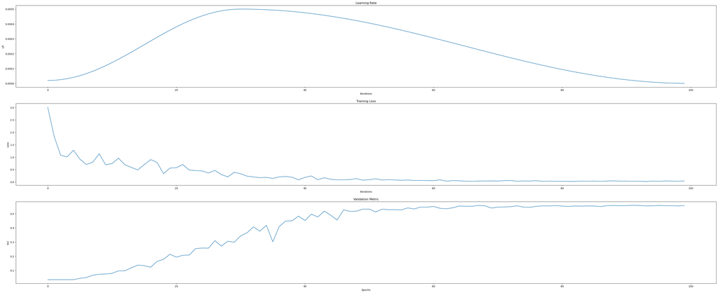

```python
pbar = tqdm(total=TOTAL_STEPS, desc='Training')
for epoch in range(epochs):
    model.train()
    N = len(train_loader)

    for i, (sample) in enumerate(train_loader):
        # Load a batch and send it to GPU
        x = sample['image'].float().cuda()
        y = sample['mask'].float().cuda()

        # Forward pass: compute predicted y by passing x to the model.
        # y_pred = model(x, double_upsample=True)
        y_pred = model(x)
        y = y.squeeze(1).long()

        # Compute and print loss.
        loss = loss_fn(y_pred, y)

        # Before the backward pass, use the optimizer object to zero all of the
        # gradients for the variables it will update (which are the learnable
        # weights of the model).
        optimizer.zero_grad()

        ##
        ##
        # I have removed one line of the code here
        loss.backward()
        ##
        ##

        # Calling the step function on an Optimizer makes an update to its parameters
        optimizer.step()
        # learning rate scheduler step.
        scheduler.step()

        pbar.update(1)
        # Report progress. Add any extra logging info here
        current_lr = scheduler.get_last_lr()[0]
        momentum = optimizer.param_groups[0]['betas'][0]

        pbar.set_postfix({'epoch': f'{epoch+1}/{epochs}',
                          'loss': loss.item(),
                          'lr': current_lr,
                          'momentum': momentum,
                          'epoch%': "{0:.1f}%".format(100*(i+1)/N)})

        if i % loss_log_interval == 0:
            log_term_dict['loss'].append(loss.item())
            log_term_dict['lr'].append(current_lr)


    # Validation after every x epoch
    if (epoch+1) % 1 == 0:
        log_term = validate(model, test_loader)
        log_term_dict['val_metric'].append(log_term)
        print("Epoch {}, total IoU: {}".format(epoch+1, log_term))

torch.save(model.state_dict(), save_path)
print('\nTraining done. Model saved ({}).'.format(save_path))

plt.figure()
plt.figure(figsize=(50, 20))
plt.subplot(3, 1, 2)
x = [i for i in range(len(log_term_dict['loss']))]
plt.plot(x, log_term_dict['loss'])
plt.title('Training Loss')
plt.xlabel('Iterations')
plt.ylabel('Loss')
plt.subplot(3, 1, 3)
x = [i for i in range(len(log_term_dict['val_metric']))]
plt.plot(x, log_term_dict['val_metric'])
plt.title('Validation Metric')
plt.xlabel('Epochs')
plt.ylabel('IoU')
plt.subplot(3, 1, 1)
x = [i for i in range(len(log_term_dict['lr']))]
plt.plot(x, log_term_dict['lr'])
plt.title('Learning Rate')
plt.xlabel('Iterations')
plt.ylabel('LR')
plt.savefig('training_log_plot_{}.png'.format(run_id))
```

```python
import re
def parse_run_id(run_id):
    pattern = r"model_n(\d+)_bs(\d+)_lr([\d.]+)_wd([\d.]+)"
    match = re.match(pattern, run_id)
    if match:
        epochs = int(match.group(1))
        batch_size = int(match.group(2))
        learning_rate = float(match.group(3))
        wd = float(match.group(4))
        return epochs, batch_size, learning_rate, wd
```

```python
print(parse_run_id('model_n50_bs16_lr0.001_wd0.0001'))
```

```
(50, 16, 0.001, 0.0001)
```

```python
import pandas as pd
results_df = pd.DataFrame(columns=['name', 'epoch', 'bs', 'lr', 'wd', 'Loss', 'total IoU'])
```

```python
def res(name, epoch, bs, lr, wd, Loss, IoU):
    global results_df
    test_dict = {
        'name': name,
        'epoch': epoch,
        'bs': bs,
        'lr': lr,
        'wd': wd,
        'Loss': Loss,
        'total IoU': IoU
    }
    results_df = pd.concat([results_df, pd.DataFrame([test_dict])], ignore_index=True)
```

```python
def write_res(run_id):
    epoch, bs, lr, wd = parse_run_id(run_id)
    Loss = np.min(log_term_dict['loss'])
    IoU = np.max(log_term_dict['val_metric'])
    res(run_id, epoch, bs, lr, wd , Loss, IoU)
```

```python
write_res('model_n25_bs8_lr0.001_wd0.0001')
```

```python
write_res('model_n25_bs16_lr0.001_wd0.0001')
```

```python
write_res('model_n50_bs16_lr0.001_wd0.0001')
```

```python
write_res('model_n50_bs16_lr0.0001_wd0.0001')
```

```python
write_res('model_n50_bs16_lr0.0003_wd0.0001')
```

```python
write_res('model_n50_bs16_lr0.0003_wd1e-05')
```

```python
write_res('model_n50_bs16_lr0.0005_wd0.0001')
```

```python
write_res('model_n75_bs16_lr0.0005_wd0.0001')
```

```python
results_df
```

|  | name | epoch | bs | lr | wd | Loss | total IoU |
| --- | --- | --- | --- | --- | --- | --- | --- |
| 0 | model_n25_bs8_lr0.001_wd0.0001 | 25 | 8 | 0.0010 | 0.0001 | 0.160994 | 0.335800 |
| 1 | model_n25_bs16_lr0.001_wd0.0001 | 25 | 16 | 0.0010 | 0.0001 | 0.194233 | 0.337890 |
| 2 | model_n50_bs16_lr0.001_wd0.0001 | 50 | 16 | 0.0010 | 0.0001 | 0.046065 | 0.477395 |
| 3 | model_n50_bs16_lr0.0001_wd0.0001 | 50 | 16 | 0.0001 | 0.0001 | 0.225434 | 0.299257 |
| 4 | model_n50_bs16_lr0.0003_wd0.0001 | 50 | 16 | 0.0003 | 0.0001 | 0.068383 | 0.479529 |
| 5 | model_n50_bs16_lr0.0003_wd1e-05 | 50 | 16 | 0.0003 | 1.0000 | 0.087424 | 0.461805 |
| 6 | model_n50_bs16_lr0.0005_wd0.0001 | 50 | 16 | 0.0005 | 0.0001 | 0.057593 | 0.502043 |
| 7 | model_n75_bs16_lr0.0005_wd0.0001 | 75 | 16 | 0.0005 | 0.0001 | 0.030388 | 0.550862 |

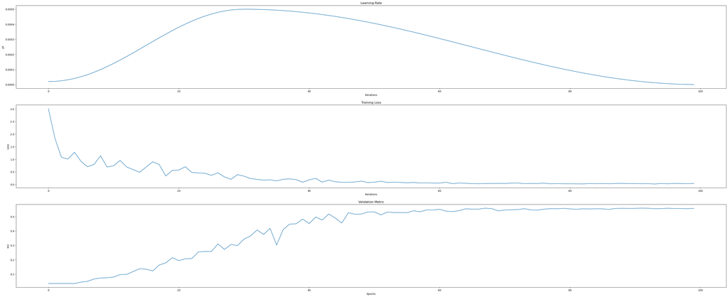

```python
plt.figure()
plt.figure(figsize=(50, 20))
plt.subplot(3, 1, 2)
x = [i for i in range(len(log_term_dict['loss']))]
plt.plot(x, log_term_dict['loss'])
plt.title('Training Loss')
plt.xlabel('Iterations')
plt.ylabel('Loss')
plt.subplot(3, 1, 3)
x = [i for i in range(len(log_term_dict['val_metric']))]
plt.plot(x, log_term_dict['val_metric'])
plt.title('Validation Metric')
plt.xlabel('Epochs')
plt.ylabel('IoU')
plt.subplot(3, 1, 1)
x = [i for i in range(len(log_term_dict['lr']))]
plt.plot(x, log_term_dict['lr'])
plt.title('Learning Rate')
plt.xlabel('Iterations')
plt.ylabel('LR')
plt.savefig('training_log_plot_{}.png'.format(run_id))
```

**Remember to answer the question!**

## Evaluation

- Evaluate your best model here
- The validation process will print a table with tons of numbers for different classes and metrics. We focus on the total - IoU one

For model_n75_bs16_lr0.0005_wd0.0001:

```python
model = Unet(BACKBONE, num_classes=21)
model.cuda()
model.load_state_dict(torch.load(save_path, map_location='cpu'))
target_metric = validate(model, test_loader, tqdm_flag=True, print_results=True)
print("Target metric: {}".format(target_metric))
```

[output not shown]

```
Validation stats                    IoU        F1      Prec    recall       Acc
Background   0.910500  0.953100  0.943900  0.962600  0.930600
Aeroplane    0.722300  0.838700  0.878100  0.802800  0.997400
Bicycle      0.405200  0.576700  0.500900  0.679500  0.996700
Bird         0.691000  0.817200  0.860700  0.778000  0.997000
Boat         0.478200  0.646900  0.706800  0.596500  0.996400
Bottle       0.511000  0.676400  0.843100  0.564700  0.995700
Bus          0.751800  0.858300  0.941800  0.788500  0.995400
Car          0.629200  0.772300  0.738700  0.809300  0.992800
Cat          0.691500  0.817600  0.782600  0.855900  0.991300
Chair        0.174900  0.297700  0.234900  0.406400  0.983500
Cow          0.463500  0.633400  0.631200  0.635700  0.991100
Diningtable  0.403600  0.575100  0.666000  0.506000  0.991400
Dog          0.597800  0.748200  0.793500  0.707900  0.990200
Horse        0.474400  0.643400  0.760300  0.557800  0.993300
Motorbike    0.567900  0.724300  0.716700  0.732300  0.994200
Person       0.713300  0.832600  0.827700  0.837700  0.982100
Pottedplant  0.332800  0.499400  0.640700  0.409200  0.995700
Sheep        0.544700  0.705200  0.647600  0.774200  0.995000
Sofa         0.291200  0.451000  0.561400  0.377000  0.987000
Train        0.606900  0.755300  0.877800  0.662900  0.992900
Tvmonitor    0.605100  0.753900  0.867700  0.666600  0.997000
total        0.550800  0.694129  0.734386  0.671976  0.989843
total(-bg)   0.532815  0.681180  0.723910  0.657445  0.992805
Target metric: 0.5508000000000001
```

For model_n100_bs16_lr0.0005_wd0.0001:

```python
model = Unet(BACKBONE, num_classes=21)
model.cuda()
model.load_state_dict(torch.load(save_path, map_location='cpu'))
target_metric = validate(model, test_loader, tqdm_flag=True, print_results=True)
print("Target metric: {}".format(target_metric))
```

```
Validation stats                    IoU        F1      Prec    recall       Acc
Background   0.911700  0.953800  0.942900  0.965100  0.931500
Aeroplane    0.701300  0.824400  0.820400  0.828500  0.997100
Bicycle      0.393800  0.565000  0.465300  0.719300  0.996400
Bird         0.607700  0.756000  0.720300  0.795400  0.995500
Boat         0.508200  0.673800  0.814800  0.574500  0.996900
Bottle       0.489100  0.656900  0.768000  0.573900  0.995200
Bus          0.699200  0.822900  0.799200  0.848200  0.993500
Car          0.669800  0.802200  0.873800  0.741500  0.994500
Cat          0.706900  0.828200  0.804200  0.853900  0.992000
Chair        0.186800  0.314800  0.263200  0.391600  0.985300
Cow          0.533600  0.695800  0.697200  0.694500  0.992700
Diningtable  0.395400  0.566600  0.744600  0.457400  0.992000
Dog          0.616200  0.762500  0.869500  0.679000  0.991300
Horse        0.489200  0.657000  0.682100  0.633700  0.992800
Motorbike    0.604100  0.753100  0.756400  0.750000  0.994900
Person       0.728900  0.843100  0.842900  0.843500  0.983300
Pottedplant  0.344500  0.512400  0.667900  0.415700  0.995800
Sheep        0.608900  0.756900  0.769000  0.745300  0.996300
Sofa         0.317400  0.481800  0.548500  0.429700  0.986900
Train        0.619000  0.764700  0.915000  0.656800  0.993300
Tvmonitor    0.569900  0.726000  0.790500  0.671300  0.996500
total        0.557219  0.700852  0.740748  0.679467  0.990176
total(-bg)   0.539495  0.688205  0.730640  0.665185  0.993110
Target metric: 0.5572190476190476
```

## Visualization [5 points]

- Use the `decode_segmap` function to visualize images and their Ground Truth and Predicted segmentation maps. The images must be from the validation set.

[output not shown]

[figure not shown]

```
Visualization saved as: visualization_model_n75_bs16_lr0.0005_wd0.0001.png
```

```python
# TODO: Implement visualization
from torchvision.utils import make_grid
import matplotlib.pyplot as plt

test_loader = DataLoader(ds_voc['val'], batch_size=1, num_workers=1, shuffle=False, sampler=None)
loader = iter(test_loader)

sample = next(loader)
x = sample['image'].float().cuda()

model = Unet(BACKBONE, num_classes=21)
model.cuda()
model.load_state_dict(torch.load(save_path, map_location='cpu'))
y_pred, y = model(x), sample['mask']

# TODO: Implement visualization
y_pred = torch.argmax(y_pred, dim=1).cpu()[0].numpy()
y = sample['mask'][0].numpy()

pred_rgb = decode_segmap(y_pred)
gt_rgb = decode_segmap(y)

input_img = sample['image'][0].permute(1, 2, 0).numpy()

input_img = np.clip(input_img, 0, 1)  # Clip to valid range

plt.figure(figsize=(15, 5))

plt.subplot(1, 3, 1)
plt.imshow(input_img)
plt.title('Input Image', fontsize=14)
plt.axis('off')

plt.subplot(1, 3, 3)
plt.imshow(gt_rgb)
plt.title('Ground Truth', fontsize=14)
plt.axis('off')

plt.subplot(1, 3, 2)
plt.imshow(pred_rgb)
plt.title('Prediction', fontsize=14)
plt.axis('off')
plt.show()

print(f"Visualization saved as: visualization_{run_id}.png")
```

[figure not shown]

```
Visualization saved as: visualization_model_n100_bs16_lr0.0005_wd0.0001.png
```

```python
# TODO: Implement visualization
from torchvision.utils import make_grid
import matplotlib.pyplot as plt

test_loader = DataLoader(ds_voc['val'], batch_size=1, num_workers=1, shuffle=False, sampler=None)
loader = iter(test_loader)

sample = next(loader)
x = sample['image'].float().cuda()

model = Unet(BACKBONE, num_classes=21)
model.cuda()
model.load_state_dict(torch.load(save_path, map_location='cpu'))
y_pred, y = model(x), sample['mask']

# TODO: Implement visualization
y_pred = torch.argmax(y_pred, dim=1).cpu()[0].numpy()
y = sample['mask'][0].numpy()

pred_rgb = decode_segmap(y_pred)
gt_rgb = decode_segmap(y)

input_img = sample['image'][0].permute(1, 2, 0).numpy()

input_img = np.clip(input_img, 0, 1)  # Clip to valid range

plt.figure(figsize=(15, 5))

plt.subplot(1, 3, 1)
plt.imshow(input_img)
plt.title('Input Image', fontsize=14)
plt.axis('off')

plt.subplot(1, 3, 3)
plt.imshow(gt_rgb)
plt.title('Ground Truth', fontsize=14)
plt.axis('off')

plt.subplot(1, 3, 2)
plt.imshow(pred_rgb)
plt.title('Prediction', fontsize=14)
plt.axis('off')
plt.show()

print(f"Visualization saved as: visualization_{run_id}.png")
```

It was the best result i had, but then i tried to run another cases. Yes i had saved file: model_n100_bs16_lr0.0005_wd0.0001.pkl but i just wanted to be shown the process of training for my best model, unfortunately when i retrained, i could not obtain same results and i had new model_n100_bs16_lr0.0005_wd0.0001.pkl pkl file, and lost old version.